# Lab 4 - Visualizing data

Fred Clavel

February 5, 2019

- [Website](http://clavelresearch.wordpress.com)
- [Github](http://github.com/fdclavel)
- [Twitter](http://twitter.com/fdclavel)

*Back to Repository Home*

# HW2 - General Notes and Questions:

**Steps for conducting statistical tests:** 1. Test assumptions 2. Run your tests 3. Interpret the results 4. Visualize (optional)

## Boxplots

Boxplots are useful for getting an idea of the variability of your data by group. **They DO NOT show you group means - the measures of central tendency captured are *medians.***

The outer edges of the boxes are the Q1 upper and Q3 lower boundaries (in other words the 25th and 75th percentiles, or more simply **the middle 50%**), while the tails of the boxes show the outer ends of the normal range (the 1st and 99th percentiles). Any extreme values are represented as dots beyond the normal range.

## Mean plots

# Examples

Use the mtcars data set as an example. It is embedded in base R and in ggplot

Call the data:

```r
library(ggplot2)
data("mtcars")
```

## Histogram

We can use the hist() function to do a quick and dirty visualization of mpg.

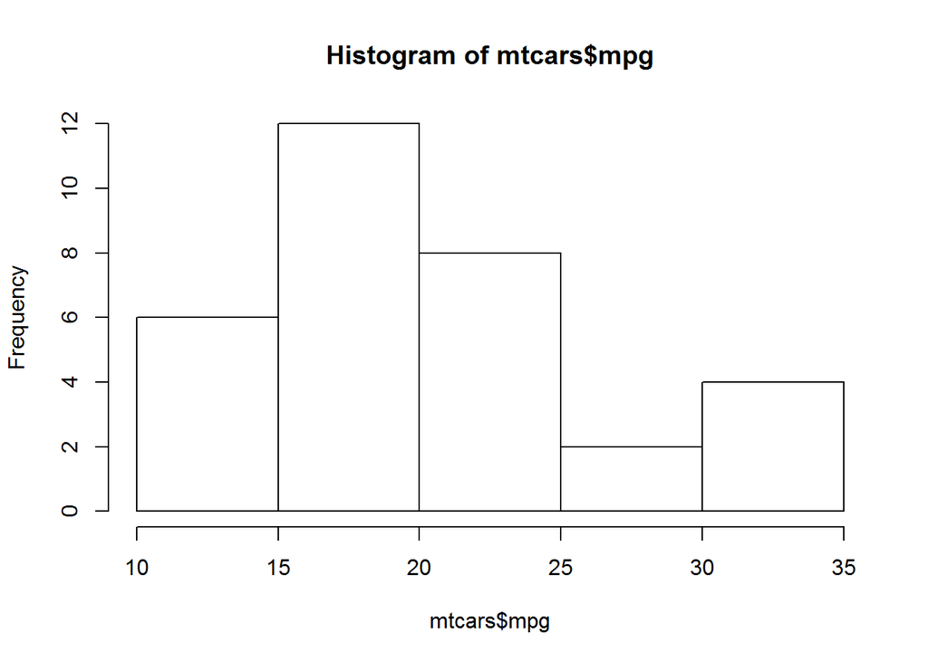

```r
hist(mtcars$mpg)
```

## Boxplot

We can also generate box plots using base R or ggplot:

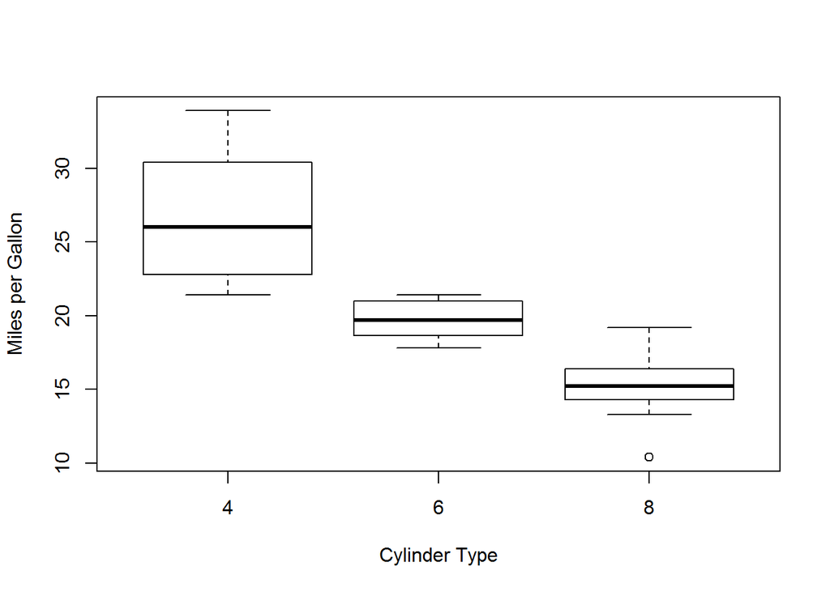

```r
boxplot(mtcars$mpg~mtcars$cyl, ylab="Miles per Gallon", xlab="Cylinder Type")
```

[figure not shown]

```r
#using ggplot
#NOTE --- you need to add "group=" if your groups are numerically coded****

ggplot(mtcars, aes(group=cyl, x=cyl, y=mpg))+
  geom_boxplot(fill="gray") +
  labs(title ="MPG by Cylinder Number", x= "Miles per Gallon", y = "Cylinder Type")+
  theme_classic()
```

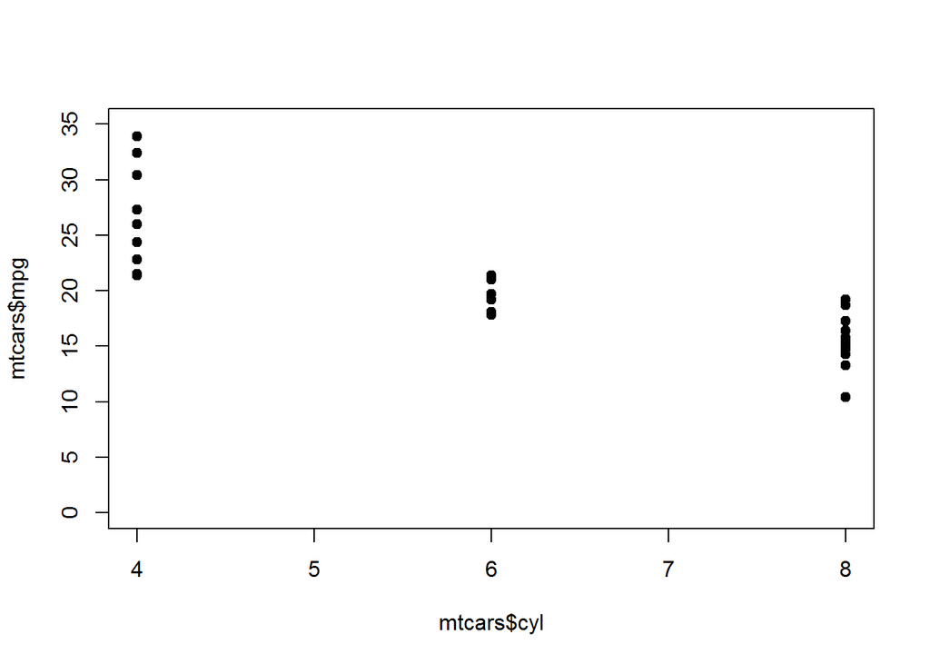

```r
#using base R
#pch =""  <- defines the shape of the data points in the plot
plot(x=mtcars$cyl, y=mtcars$mpg, ylim=c(0,35), xlim=c(4,8),
     pch=19)
```

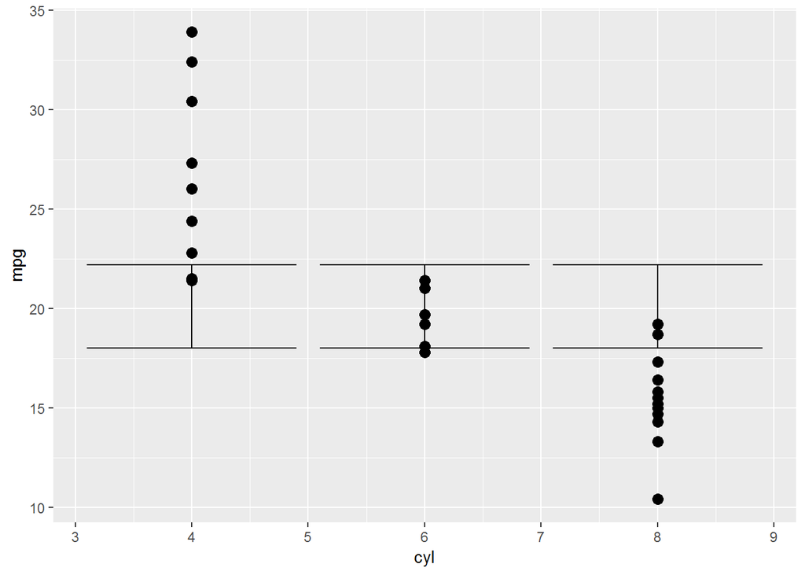

```r
#Getting the CIs for the means in base R is pretty brutal. don't bother. use ggplot.

#We will need the standard error of the miles per gallon variable in order to compute CIs.

stddev<-sd(mtcars$mpg)
se <- sd(mtcars$mpg) / sqrt(length(mtcars$mpg))
ggplot(mtcars, aes(x=cyl, y=mpg)) +
  geom_point(shape=19, size=3)+
  geom_errorbar(aes(ymin=(mean(mtcars$mpg))-1.96*se, ymax=(mean(mtcars$mpg))+1.96*se ))
```